# Evidence1.1

#### **Production of energy in the last year registered for each country**

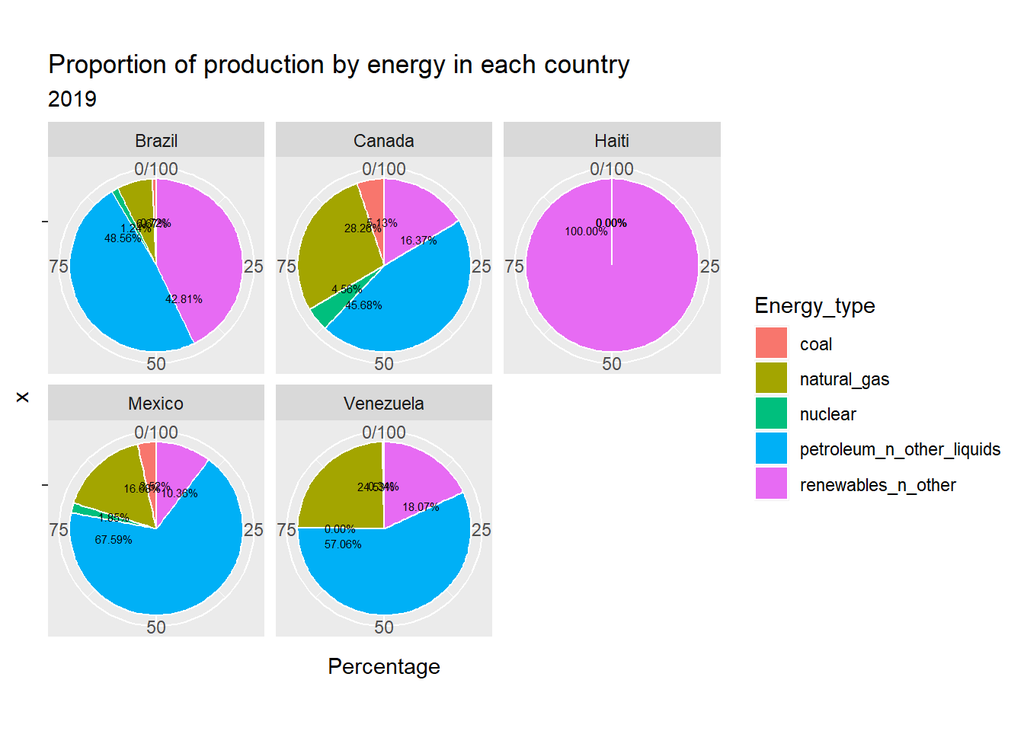

```r
energy_production_2019<-energy%>%
  filter(Year==2019, Energy_type!="all_energy_types")%>%
  group_by(Country)%>%
  mutate(Total=sum(Energy_production), Percentage=Energy_production/Total*100)

ggplot(data=energy_production_2019,aes(x="",y=Percentage, fill=Energy_type))+
  geom_bar(stat = "identity",color="white")+
    geom_text(aes(label=percent(Percentage/100)),
              position=position_stack(vjust=0.9),color="black",size=2)+
  coord_polar(theta="y")+
  facet_wrap(~Country)+
  labs(title="Proportion of production by energy in each country",
       subtitle="2019")
```

In the proportion of production of energy in each country, we did a pie chart where we can see that Brazil, Canada, Mexico, and Venezuela have most of their production focused on petroleum while Haiti has it in renewables.

#### **Growth**

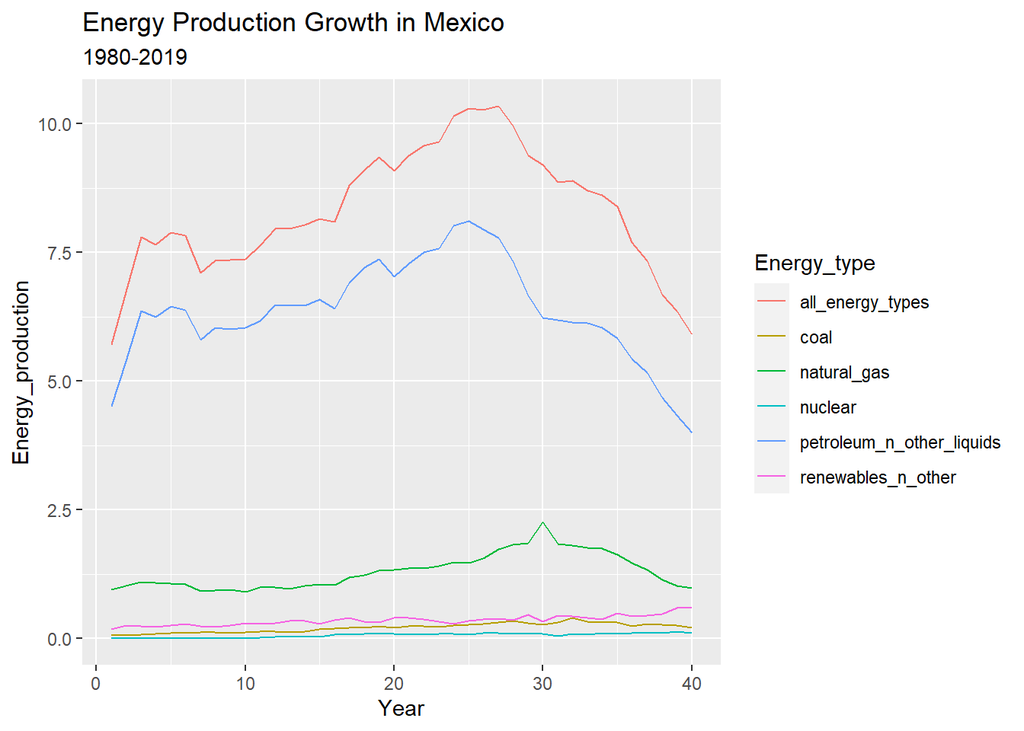

```r
energy_production_mexico<-energy%>%
  filter( Country=="Mexico")%>%
  mutate(Year=as.numeric(Year))%>%
  group_by(Energy_type)

ggplot(data=energy_production_mexico, mapping=aes(x=Year, y=Energy_production, color=Energy_type))+
  geom_line()+
  labs(title="Energy Production Growth in Mexico",
       subtitle="1980-2019")
```

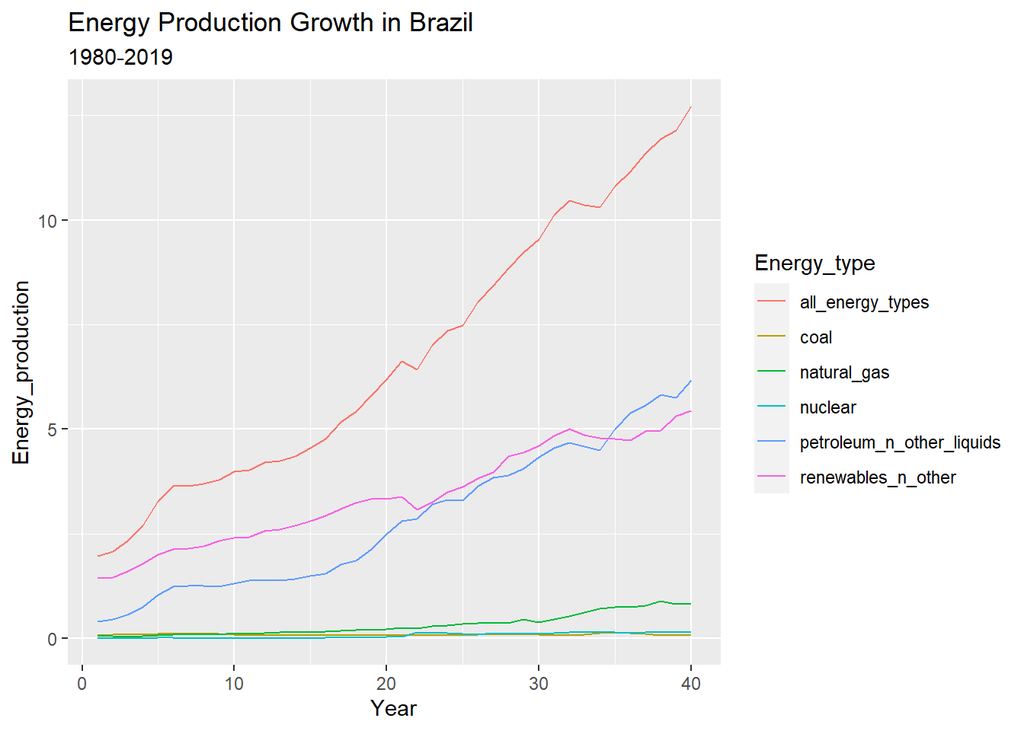

```r
energy_production_brazil<-energy%>%
  filter( Country=="Brazil")%>%
  mutate(Year=as.numeric(Year))%>%
  group_by(Energy_type)

ggplot(data=energy_production_brazil, mapping=aes(x=Year, y=Energy_production, color=Energy_type))+
  geom_line()+
  labs(title="Energy Production Growth in Brazil",
       subtitle="1980-2019")
```

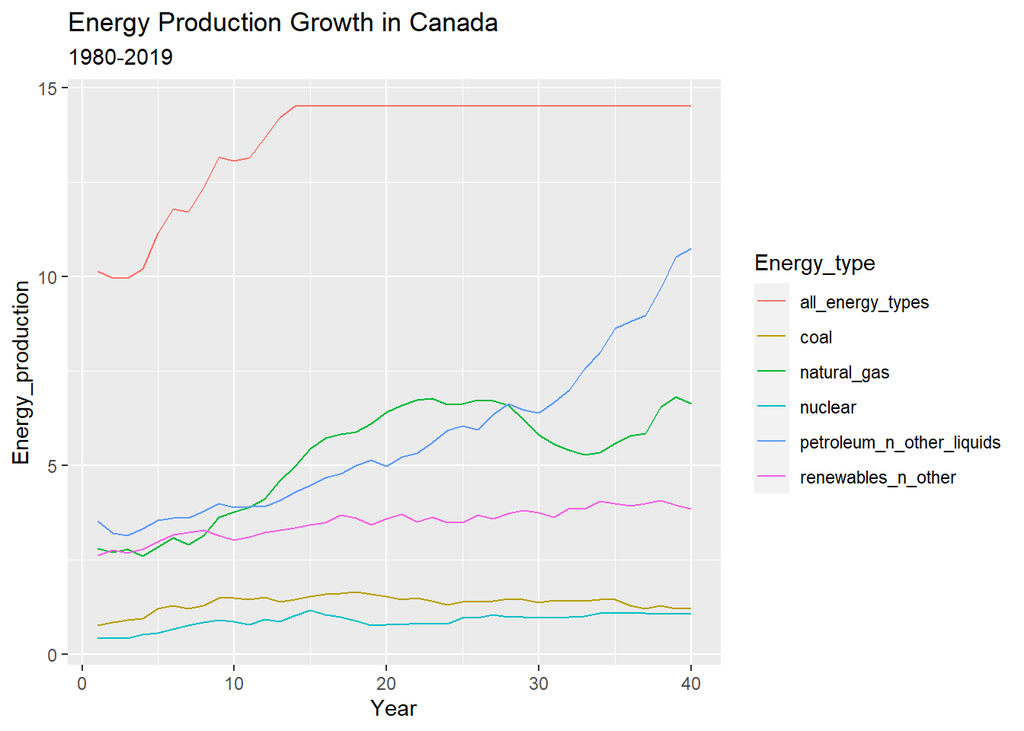

```r
energy_production_canada<-energy%>%
  filter( Country=="Canada")%>%
  mutate(Year=as.numeric(Year))%>%
  group_by(Energy_type)

ggplot(data=energy_production_canada, mapping=aes(x=Year, y=Energy_production, color=Energy_type))+
  geom_line()+
  labs(title="Energy Production Growth in Canada",
       subtitle="1980-2019")
```

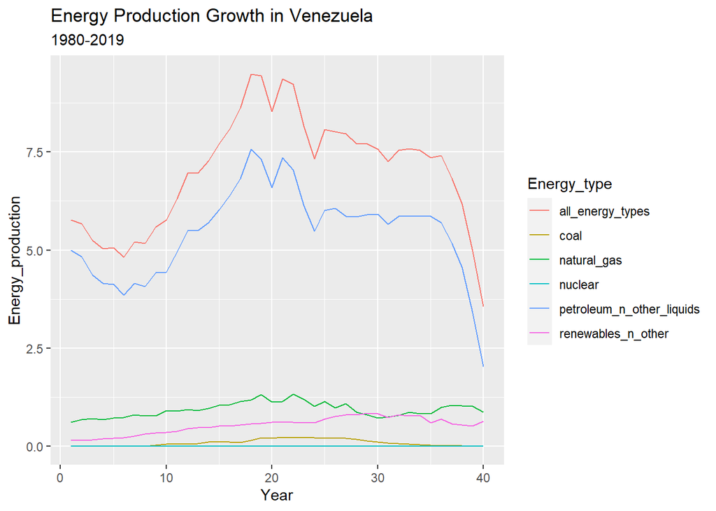

```r
energy_production_venezuela<-energy%>%
  filter( Country=="Venezuela")%>%
  mutate(Year=as.numeric(Year))%>%
  group_by(Energy_type)

ggplot(data=energy_production_venezuela, mapping=aes(x=Year, y=Energy_production, color=Energy_type))+
  geom_line()+
  labs(title="Energy Production Growth in Venezuela",
       subtitle="1980-2019")
```

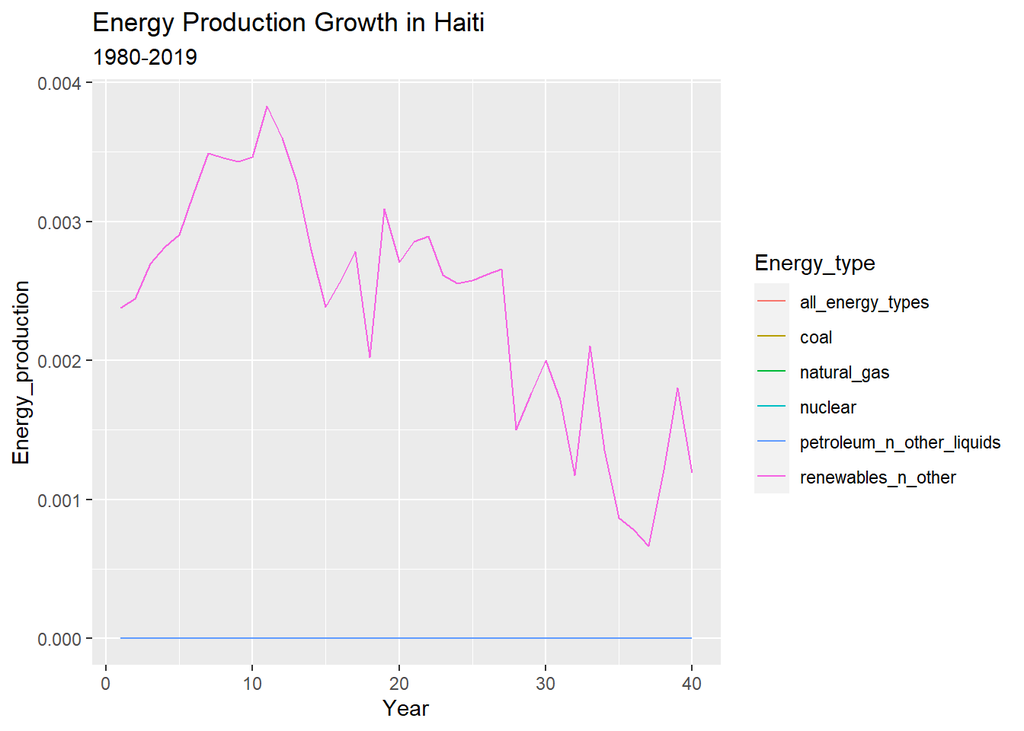

```r
energy_production_haiti<-energy%>%
  filter( Country=="Haiti")%>%
  mutate(Year=as.numeric(Year))%>%
  group_by(Energy_type)

ggplot(data=energy_production_haiti, mapping=aes(x=Year, y=Energy_production, color=Energy_type))+
  geom_line()+
  labs(title="Energy Production Growth in Haiti",
       subtitle="1980-2019")
```

With a line graph did it with ggplot2 and the function *geom_line*, we looked for the production growth in each country and by energy type. In Mexico, there was an increase in petroleum but then went down as well with natural gas. In Brazil, petroleum and renewables have increased and also we can see a little one in natural gas.

### **GDP**

Then we did the analysis for GDP.

#### **Mean and Standard Deviation**

The mean of all the studied countries is 1052.

```r
mean(energy$GDP)
```

```
## [1] 1052
```

```r
sd(energy$GDP)
```

```
## [1] 852
```

**For each country**

```r
group_by(energy, Country)%>%
  filter(Energy_type!= "all_energy_types")%>%
  summarize(mean=mean(GDP))%>%
  arrange(desc(mean))
```

```
## # A tibble: 5 × 2
##   Country     mean
##   <fct>      <dbl>
## 1 Brazil    2097.
## 2 Mexico    1598.
## 3 Canada    1166.
## 4 Venezuela  380.
## 5 Haiti       21.4
```

```r
group_by(energy, Country)%>%
  filter(Energy_type!= "all_energy_types")%>%
  summarize(sd=sd(GDP))%>%
  arrange(desc(sd))
```

```
## # A tibble: 5 × 2
##   Country      sd
##   <fct>     <dbl>
## 1 Brazil    634.
## 2 Mexico    441.
## 3 Canada    322.
## 4 Venezuela  96.1
## 5 Haiti      11.0
```

#### **Distribution**

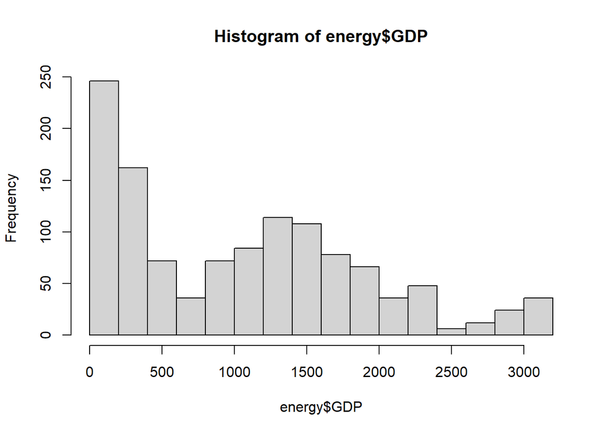

```r
hist(energy$GDP)
```

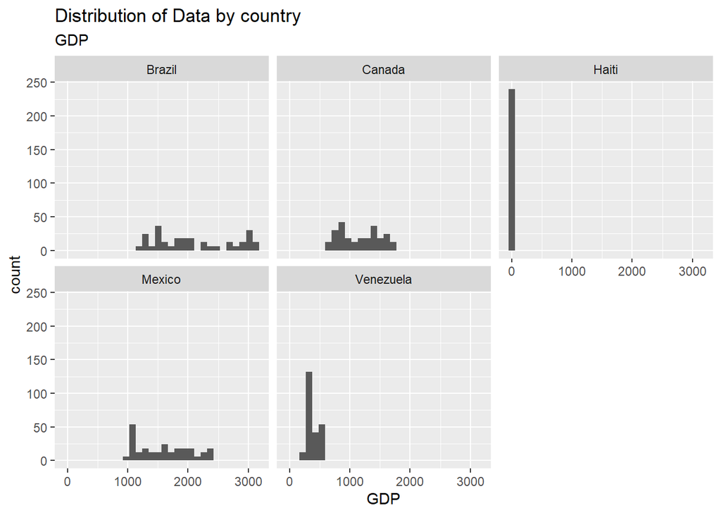

```r
ggplot(energy, aes(x=GDP))+
  geom_histogram()+
  facet_wrap(~Country)+
  labs(title="Distribution of Data by country",
       subtitle="GDP")
```

In the distribution of the data, using the *hist* function, we see the next distribution of all registries and by country.

#### **GDP of each country**

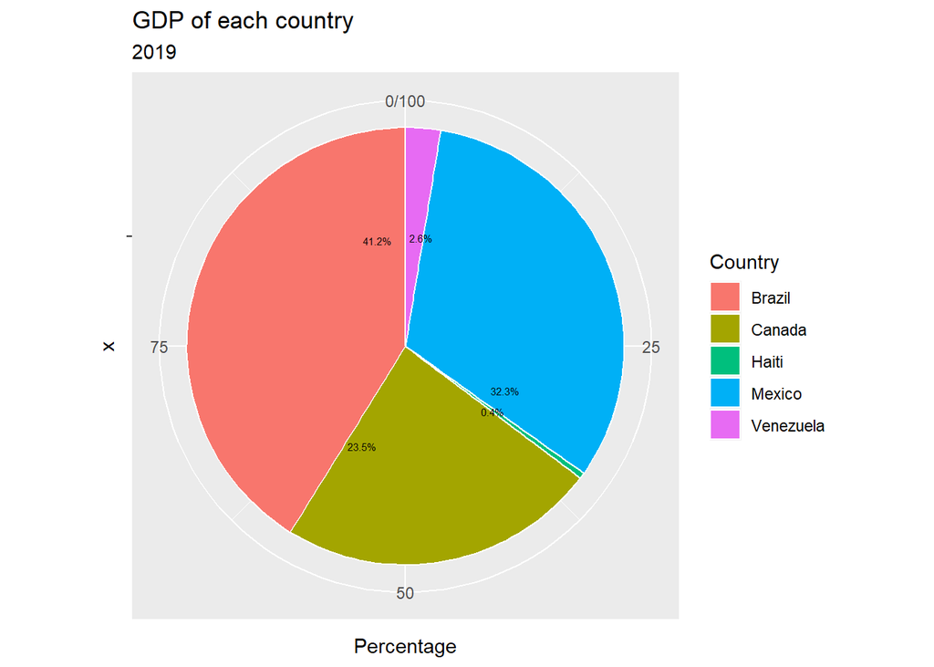

```r
GDP_2019<-energy%>%
  filter(Year==2019, Energy_type=="all_energy_types")%>%
  mutate(Total=sum(GDP), Percentage=GDP/Total*100)

ggplot(data=GDP_2019,aes(x="",y=Percentage, fill=Country))+
  geom_bar(stat = "identity",color="white")+
    geom_text(aes(label=percent(Percentage/100)),
              position=position_stack(vjust=0.9),color="black",size=2)+
  coord_polar(theta="y")+
  labs(title="GDP of each country",
       subtitle="2019")
```

Then we did the analysis of the proportion of GDP between countries, Brazil is the one with the highest GDP.

#### **Growth**

Finally, we looked at the growth of each country. As we see, Brazil, Canada, and Mexico are the ones that had shown an increase while Venezuela and Haiti don’t.

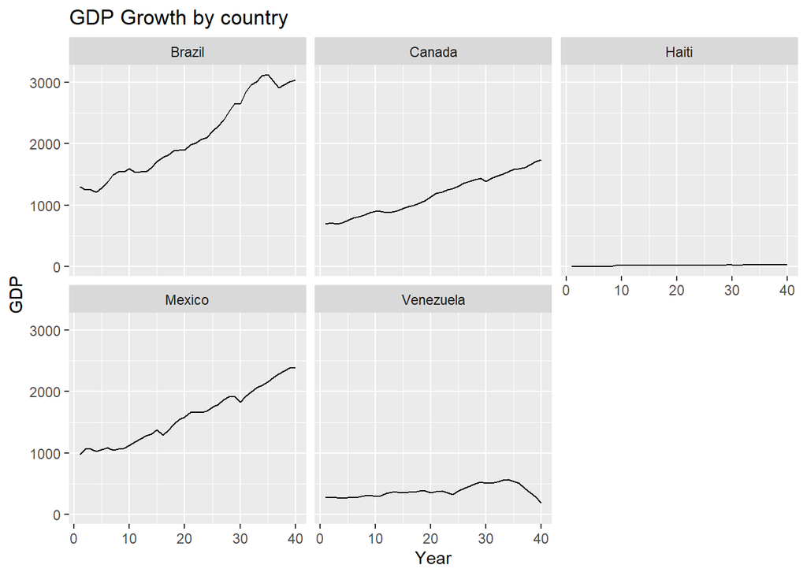

```r
energy_GDP_mexico<-energy%>%
  mutate(Year=as.numeric(Year))

ggplot(data=energy_GDP_mexico, mapping=aes(x=Year, y=GDP))+
  geom_line()+
  facet_wrap(~Country)+
  labs(title="GDP Growth by country")
```

### **Energy intensity by GDP**

#### **Mean and Standard Deviation**

The total mean of all countries is 5.29 and with a standard deviation of 3.55 in Energy intensity by GDP.

```r
mean(energy$Energy_intensity_by_GDP)
```

```
## [1] 5.29
```

```r
sd(energy$Energy_intensity_by_GDP)
```

```
## [1] 3.55
```

**For each country**

```r
group_by(energy, Country)%>%
  filter(Energy_type!= "all_energy_types")%>%
  summarize(mean=mean(Energy_intensity_by_GDP))%>%
  arrange(desc(mean))
```

```
## # A tibble: 5 × 2
##   Country     mean
##   <fct>      <dbl>
## 1 Canada    11.0
## 2 Venezuela  6.86
## 3 Mexico     3.93
## 4 Brazil     3.81
## 5 Haiti      0.843
```

```r
group_by(energy, Country)%>%
  filter(Energy_type!= "all_energy_types")%>%
  summarize(sd=sd(Energy_intensity_by_GDP))%>%
  arrange(desc(sd))
```

```
## # A tibble: 5 × 2
##   Country      sd
##   <fct>     <dbl>
## 1 Canada    1.45
## 2 Venezuela 1.26
## 3 Haiti     0.508
## 4 Brazil    0.398
## 5 Mexico    0.252
```

By country, we can see that Canada is, again, the highest with 10.98 and Haiti lowest with 0.843.

#### **Distribution**

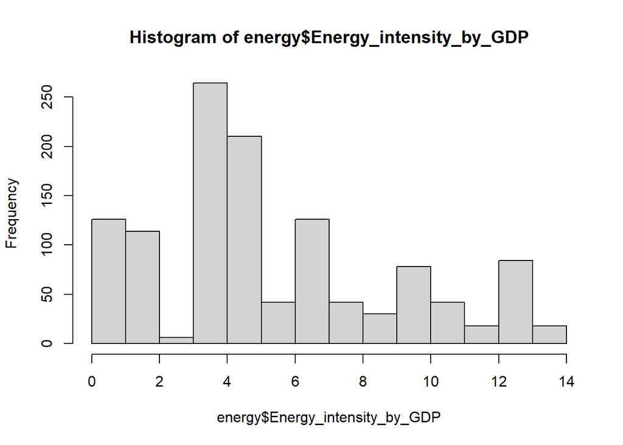

```r
hist(energy$Energy_intensity_by_GDP)
```

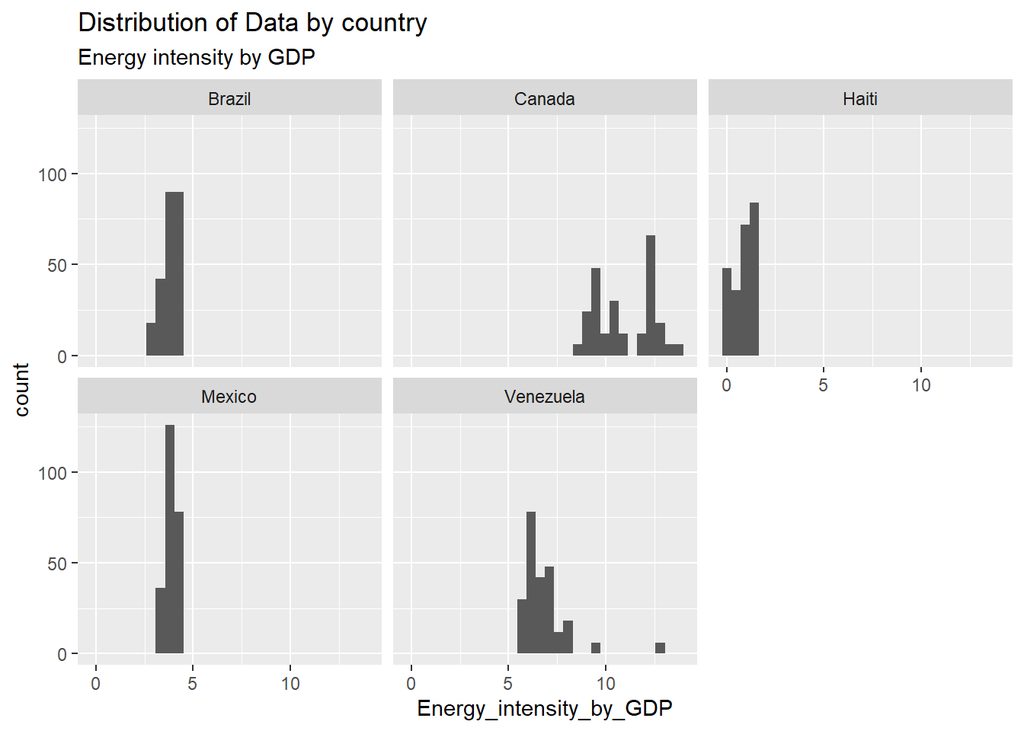

```r
ggplot(energy, aes(x=Energy_intensity_by_GDP))+
  geom_histogram()+
  facet_wrap(~Country)+
  labs(title="Distribution of Data by country",
       subtitle="Energy intensity by GDP")
```

In the distribution, we can see that this case is different from the one of energy consumption, energy production, and GDP. From the total data of Energy Intensity by GDP we see that most of it is located almost in the first places, something similar happens when is divided by countries unless Venezuela and Canada, where most of its registries are located in the medium and in the final.

#### **Growth**

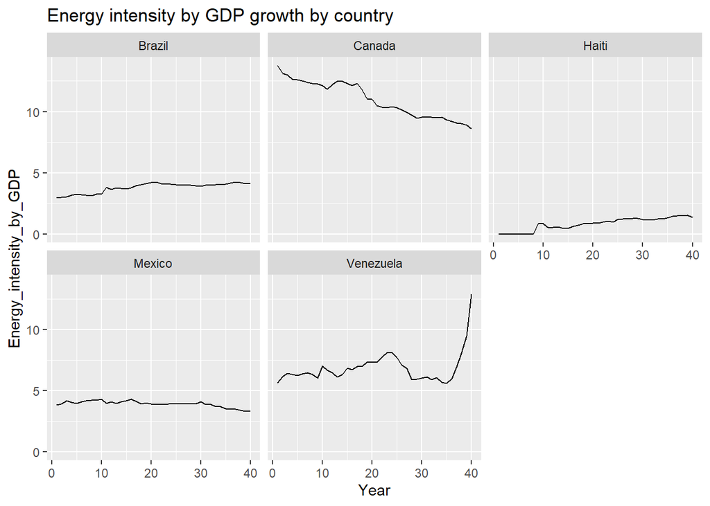

```r
energy_int_GDP_mexico<-energy%>%
  mutate(Year=as.numeric(Year))

ggplot(data=energy_int_GDP_mexico, mapping=aes(x=Year, y=Energy_intensity_by_GDP))+
  geom_line()+
  facet_wrap(~Country)+
  labs(title="Energy intensity by GDP growth by country")
```

In growth, we can see that Venezuela has the highest increase in intensity by GDP, Canada presents a decrease, and Brazil, Mexico, and Haiti almost maintain the same.

### **CO2 Emissions**

We also did the analysis of CO2 emissions, which is important for the decision-making we want to achieve at the end of this project.

#### **Mean and Standard Deviation**

The total mean is 83.6 while the standard deviation is 129, which means that there really is a big variability between data.

```r
mean(energy$CO2_emission)
```

```
## [1] 83.6
```

```r
sd(energy$CO2_emission)
```

```
## [1] 129
```

**For each country**

```r
group_by(energy, Country)%>%
  filter(Energy_type!= "all_energy_types")%>%
  summarize(mean=mean(CO2_emission))%>%
  arrange(desc(mean))
```

```
## # A tibble: 5 × 2
##   Country     mean
##   <fct>      <dbl>
## 1 Canada    98.1
## 2 Mexico    70.0
## 3 Brazil    62.6
## 4 Venezuela 23.7
## 5 Haiti      0.317
```

```r
group_by(energy, Country)%>%
  filter(Energy_type!= "all_energy_types")%>%
  summarize(sd=sd(CO2_emission))%>%
  arrange(desc(sd))
```

```
## # A tibble: 5 × 2
##   Country       sd
##   <fct>      <dbl>
## 1 Canada    99.0
## 2 Brazil    97.2
## 3 Mexico    92.8
## 4 Venezuela 31.3
## 5 Haiti      0.733
```

**By country and Energy type**

Finally, talking about mean and divided by country and energy type, the ones that produce the most CO2 emissions are Brazil, Mexico, and Canada with petroleum.

```r
group_by(energy, Country, Energy_type)%>%
  filter(Energy_type!= "all_energy_types")%>%
  summarize(mean=mean(CO2_emission))%>%
  arrange(desc(mean))
```

```
## # A tibble: 25 × 3
## # Groups:   Country [5]
##    Country   Energy_type                mean
##    <fct>     <fct>                     <dbl>
##  1 Canada    petroleum_n_other_liquids 242.
##  2 Brazil    petroleum_n_other_liquids 239.
##  3 Mexico    petroleum_n_other_liquids 232.
##  4 Canada    natural_gas               157.
##  5 Canada    coal                       92.2
##  6 Mexico    natural_gas                87.9
##  7 Venezuela petroleum_n_other_liquids  68.8
##  8 Venezuela natural_gas                49.1
##  9 Brazil    coal                       47.7
## 10 Mexico    coal                       30.1
## # … with 15 more rows
```

```r
group_by(energy, Country, Energy_type)%>%
  filter(Energy_type!= "all_energy_types")%>%
  summarize(sd=sd(CO2_emission))%>%
  arrange(desc(sd))
```

```
## # A tibble: 25 × 3
## # Groups:   Country [5]
##    Country   Energy_type                  sd
##    <fct>     <fct>                     <dbl>
##  1 Brazil    petroleum_n_other_liquids  75.8
##  2 Mexico    petroleum_n_other_liquids  56.4
##  3 Canada    petroleum_n_other_liquids  54.3
##  4 Canada    natural_gas                47.1
##  5 Mexico    natural_gas                39.4
##  6 Brazil    natural_gas                24.6
##  7 Canada    coal                       20.9
##  8 Venezuela petroleum_n_other_liquids  19.8
##  9 Mexico    coal                       17.3
## 10 Brazil    coal                       15.2
## # … with 15 more rows
```

#### **Distribution**

The distribution is viewed more at the left of the chart, while divided by country we can see almost the same behavior in Brazil, Canada, Mexico, and Venezuela. Haiti has all its data at the beginning again.

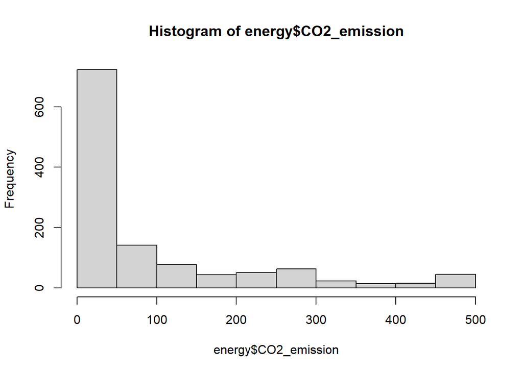

```r
hist(energy$CO2_emission)
```

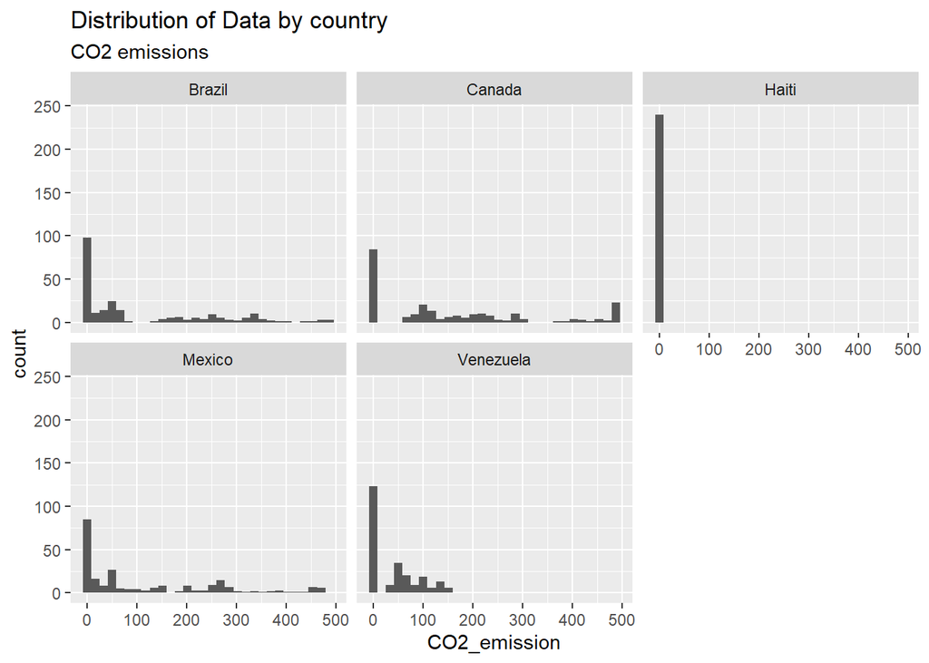

```r
ggplot(energy, aes(x=CO2_emission))+
  geom_histogram()+
  facet_wrap(~Country)+
  labs(title="Distribution of Data by country",
       subtitle="CO2 emissions")
```

#### **CO2 emissions per energy in the last recorded year for each country**

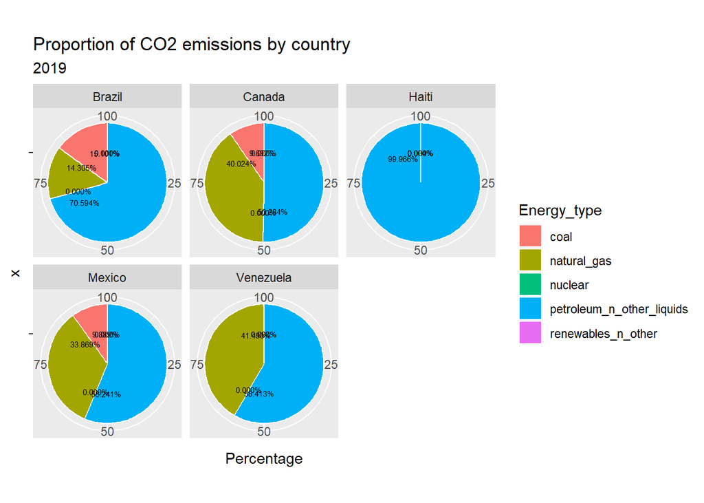

```r
CO2_2019<-energy%>%
  filter(Year==2019, Energy_type!="all_energy_types")%>%
  group_by(Country)%>%
  mutate(Total=sum(CO2_emission), Percentage=CO2_emission/Total*100)

ggplot(data=CO2_2019,aes(x="",y=Percentage, fill=Energy_type))+
  geom_bar(stat = "identity",color="white")+
    geom_text(aes(label=percent(Percentage/100)),
              position=position_stack(vjust=0.9),color="black",size=2)+
  coord_polar(theta="y")+
  facet_wrap(~Country)+
  labs(title="Proportion of CO2 emissions by country",
       subtitle="2019")
```

Divided by energy and to know the proportions, we can see that petroleum is the one that produces the most CO2 emissions in all countries, while coal and natural gas are the other ones with the most emissions.

#### **Growth**

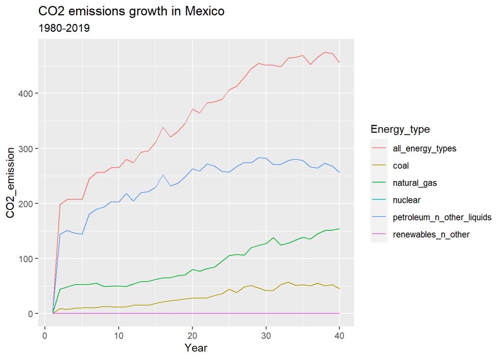

```r
energy_CO2_mexico<-energy%>%
  filter( Country=="Mexico")%>%
  mutate(Year=as.numeric(Year))%>%
  group_by(Energy_type)

ggplot(data=energy_CO2_mexico, mapping=aes(x=Year, y=CO2_emission, color=Energy_type))+
  geom_line()+
  labs(title="CO2 emissions growth in Mexico",
       subtitle="1980-2019")
```

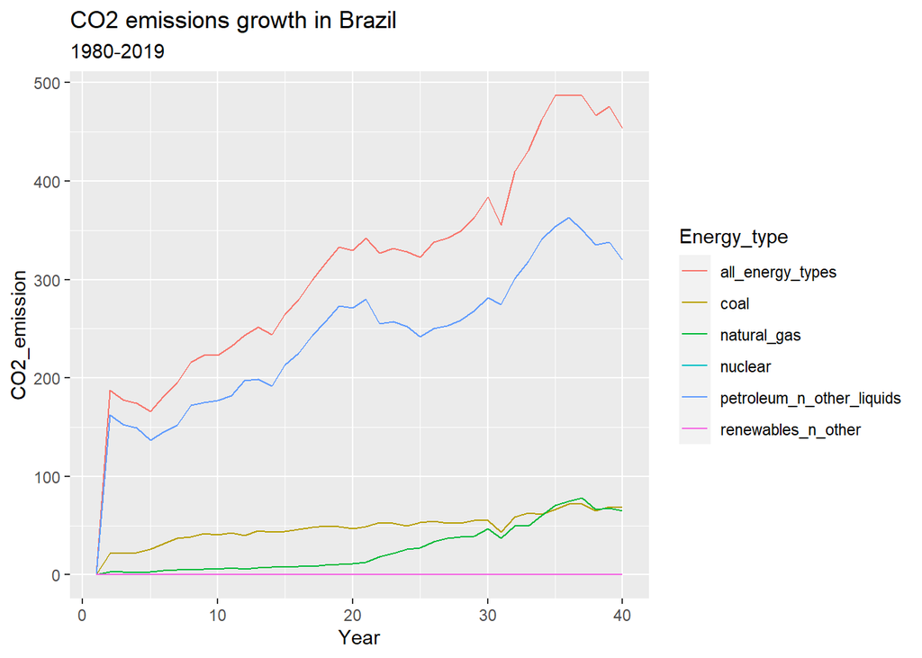

```r
energy_CO2_brazil<-energy%>%
  filter( Country=="Brazil")%>%
  mutate(Year=as.numeric(Year))%>%
  group_by(Energy_type)

ggplot(data=energy_CO2_brazil, mapping=aes(x=Year, y=CO2_emission, color=Energy_type))+
  geom_line()+
  labs(title="CO2 emissions growth in Brazil",
       subtitle="1980-2019")
```

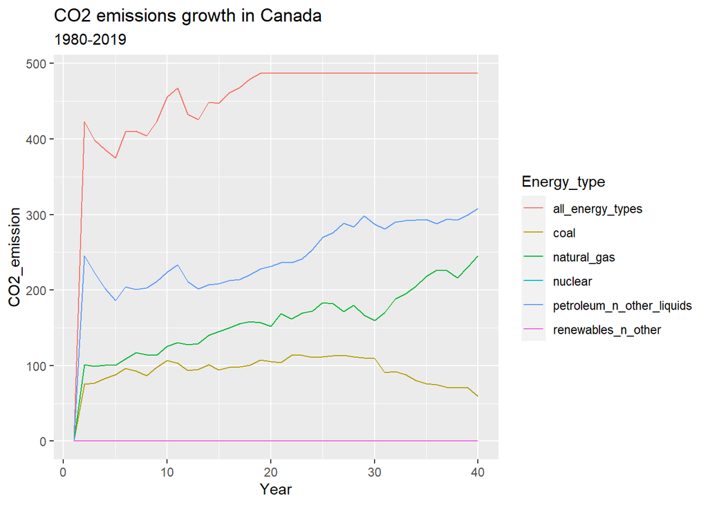

```r
energy_CO2_canada<-energy%>%
  filter( Country=="Canada")%>%
  mutate(Year=as.numeric(Year))%>%
  group_by(Energy_type)

ggplot(data=energy_CO2_canada, mapping=aes(x=Year, y=CO2_emission, color=Energy_type))+
  geom_line()+
  labs(title="CO2 emissions growth in Canada",
       subtitle="1980-2019")
```

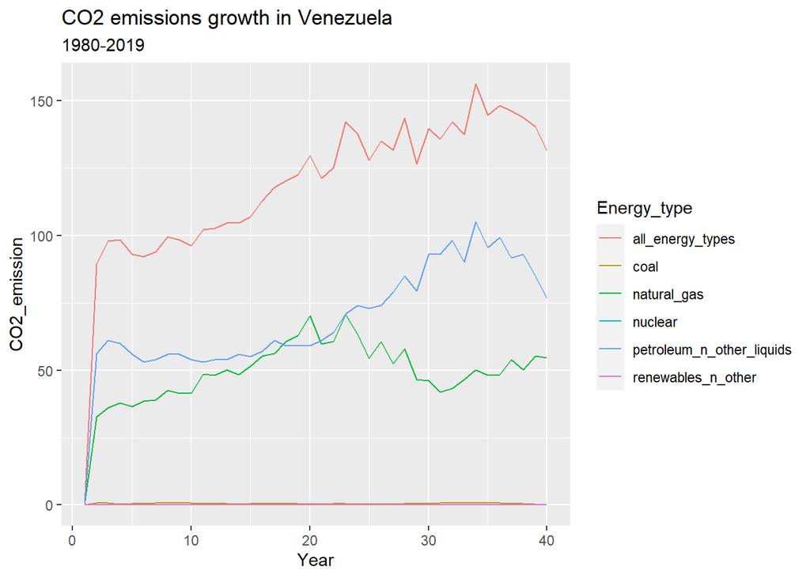

```r
energy_CO2_venezuela<-energy%>%
  filter( Country=="Venezuela")%>%
  mutate(Year=as.numeric(Year))%>%
  group_by(Energy_type)

ggplot(data=energy_CO2_venezuela, mapping=aes(x=Year, y=CO2_emission, color=Energy_type))+
  geom_line()+
  labs(title="CO2 emissions growth in Venezuela",
       subtitle="1980-2019")
```

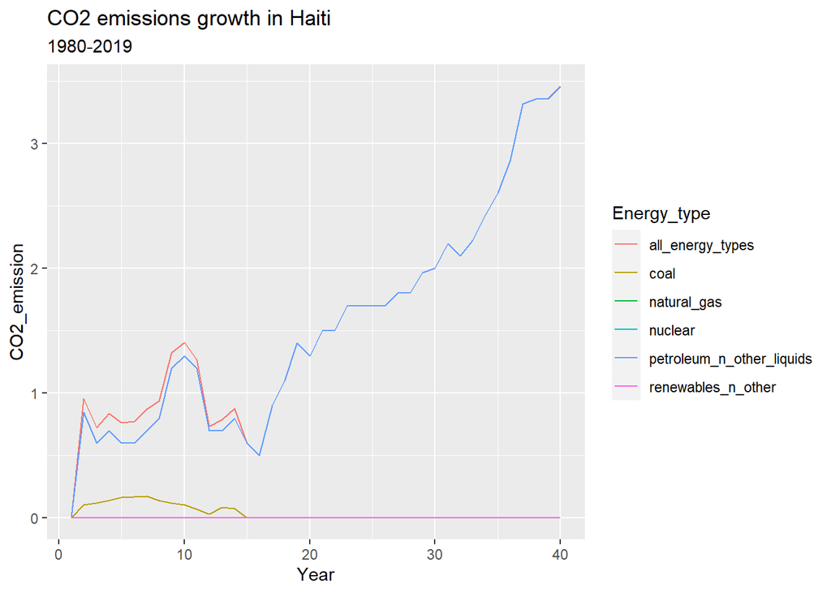

```r
energy_CO2_haiti<-energy%>%
  filter( Country=="Haiti")%>%
  mutate(Year=as.numeric(Year))%>%
  group_by(Energy_type)

ggplot(data=energy_CO2_haiti, mapping=aes(x=Year, y=CO2_emission, color=Energy_type))+
  geom_line()+
  labs(title="CO2 emissions growth in Haiti",
       subtitle="1980-2019")
```

#### **Some relations**

**Energy consumption and production**

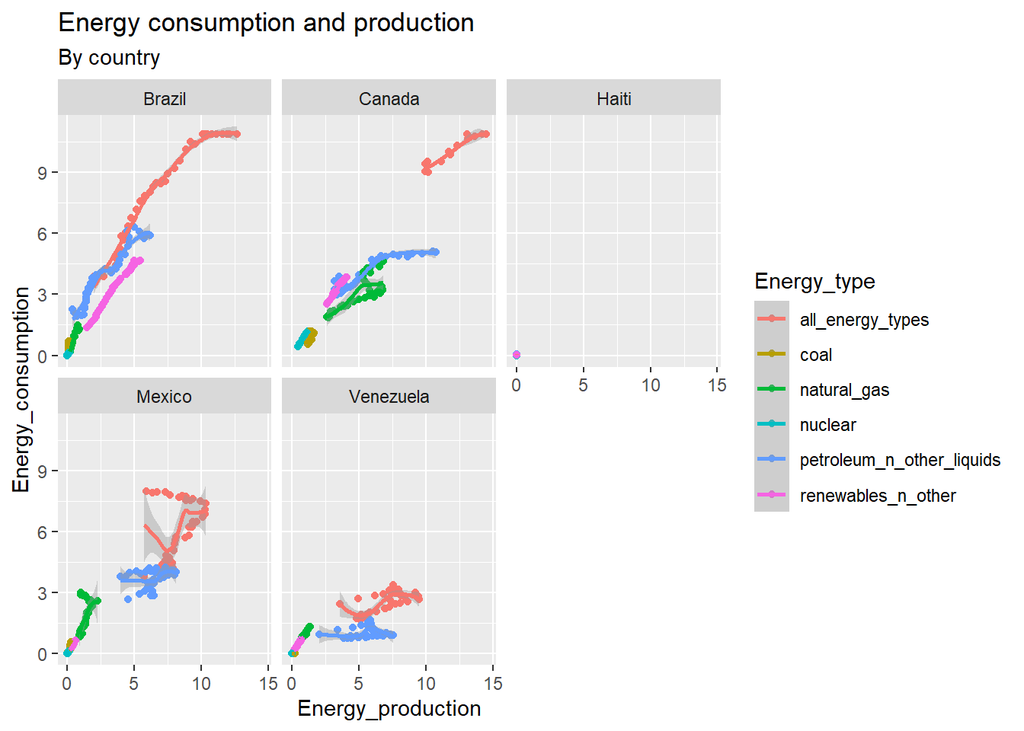

```r
energy_types<-energy%>%
  group_by(Energy_type)

ggplot(data=energy_types, mapping=aes(x=Energy_production, y=Energy_consumption, color=Energy_type))+
  geom_point()+
  geom_smooth()+
  facet_wrap(~Country)+
  labs(title="Energy consumption and production",
       subtitle="By country")
```

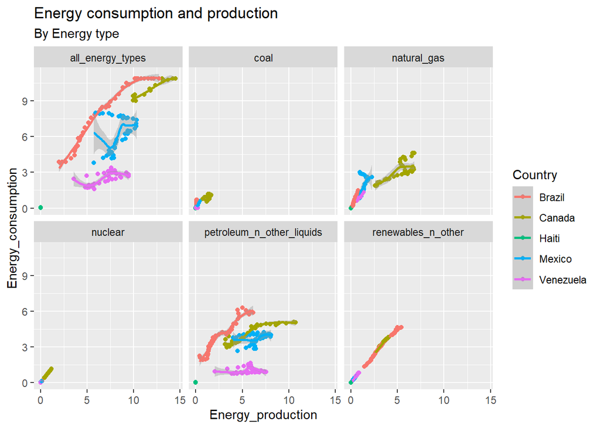

```r
energy_country<-energy%>%
  group_by(Country)

ggplot(data=energy_country, mapping=aes(x=Energy_production, y=Energy_consumption, color=Country))+
  geom_point()+
  geom_smooth()+
  facet_wrap(~Energy_type)+
  labs(title="Energy consumption and production",
       subtitle="By Energy type")
```

First, we looked at the relationship between energy consumption and production. For this (and is almost the same steps we followed for the next graphs), we grouped the database by energy type and created the tables divided by countries. We find there is not a lot of relation in some places but in Brazil and Canada is visible.

We also constructed the graphs by grouping them by country and dividing them by energy type, here we confirm that Brazil is the one that presents the strongest relationship between consumption and production, and renewables is the type with the strongest relation.

**Energy production and GDP**

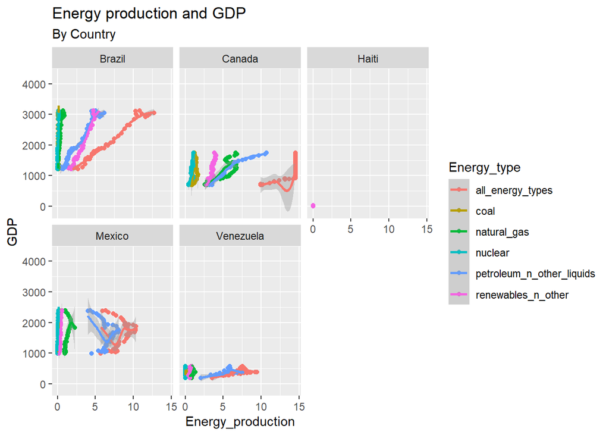

```r
ggplot(data=energy_types, mapping=aes(x=Energy_production, y=GDP, color=Energy_type))+
  geom_point()+
  geom_smooth()+
  facet_wrap(~Country)+
  labs(title="Energy production and GDP",
       subtitle="By Country")
```

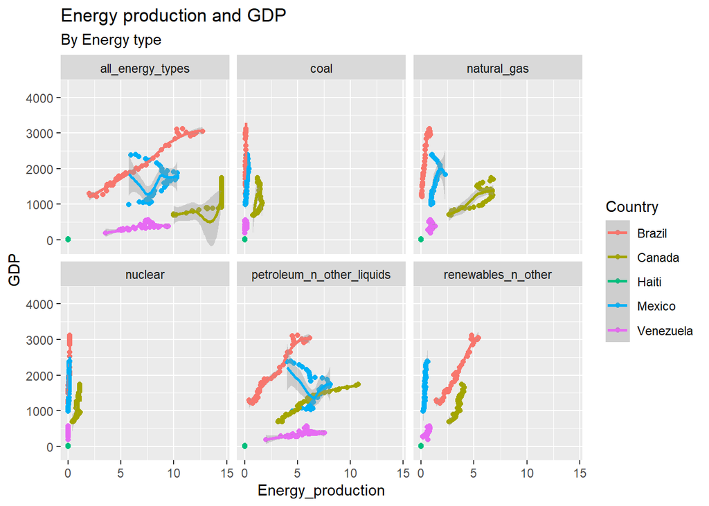

```r
ggplot(data=energy_country, mapping=aes(x=Energy_production, y=GDP, color=Country))+
  geom_point()+
  geom_smooth()+
  facet_wrap(~Energy_type)+
  labs(title="Energy production and GDP",
       subtitle="By Energy type")
```

**Energy intensity by GDP and Population**

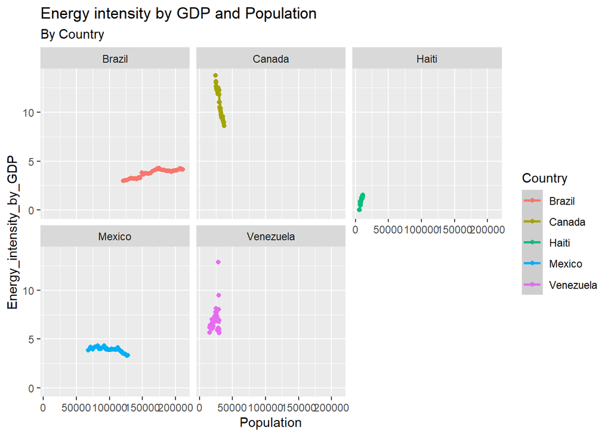

```r
ggplot(data=energy_country, mapping=aes(x=Population, y=Energy_intensity_by_GDP, color=Country))+
  geom_point()+
  geom_smooth()+
  facet_wrap(~Country)+
  labs(title="Energy intensity by GDP and Population",
       subtitle="By Country")
```

Finally, we looked at the relationship between intensity by GDP and population, which is not exactly strong and the behavior between countries is very different.

### **Some Energies**

In the dataset Consumrption is information about other energies not studied in the one of Energy, that’s why we will look for some information inside these variables in the following lines:

#### **Average and Standard Deviation**

```r
mean_sd_all_energies<-consumption%>%
  summarize(mean_oil=mean(oil_consumption), sd_oil=sd(oil_consumption), mean_other_renewable=mean(other_renewable_consumption), sd_other_renewable=sd(other_renewable_consumption), mean_renewables=mean(renewables_consumption), sd_renewables=sd(renewables_consumption), mean_wind=mean(wind_consumption), sd_wind=sd(wind_consumption), mean_solar=mean(solar_consumption), sd_solar=sd(solar_consumption))

mean_sd_all_energies
```

```
## # A tibble: 1 × 10
##   mean_…¹ sd_oil mean_…² sd_ot…³ mean_…⁴ sd_re…⁵ mean_…⁶ sd_wind mean_…⁷ sd_so…⁸
##     <dbl>  <dbl>   <dbl>   <dbl>   <dbl>   <dbl>   <dbl>   <dbl>   <dbl>   <dbl>
## 1    303.   435.    5.03    11.5    145.    254.    1.73    7.33   0.142   0.815
## # … with abbreviated variable names ¹mean_oil, ²mean_other_renewable,
## #   ³sd_other_renewable, ⁴mean_renewables, ⁵sd_renewables, ⁶mean_wind,
## #   ⁷mean_solar, ⁸sd_solar
```

First, the mean and standard deviation by energy. We see that, of these energies, the highest consumption is of oil while the lowest is solar energy.

**For each country**

```r
mean_sd_by_country<-consumption%>%
  group_by(country)%>%
  summarize(mean_oil=mean(oil_consumption), sd_oil=sd(oil_consumption), mean_other_renewable=mean(other_renewable_consumption), sd_other_renewable=sd(other_renewable_consumption), mean_renewables=mean(renewables_consumption), sd_renewables=sd(renewables_consumption), mean_wind=mean(wind_consumption), sd_wind=sd(wind_consumption), mean_solar=mean(solar_consumption), sd_solar=sd(solar_consumption))

mean_sd_by_country
```

```
## # A tibble: 5 × 11
##   country mean_…¹ sd_oil mean_…² sd_ot…³ mean_…⁴ sd_re…⁵ mean_…⁶ sd_wind mean_…⁷
##   <fct>     <dbl>  <dbl>   <dbl>   <dbl>   <dbl>   <dbl>   <dbl>   <dbl>   <dbl>
## 1 Brazil     375.   480.   10.2    18.6    238.    310.  2.46     9.10   0.115
## 2 Canada     469.   527.    6.32   10.1    302.    341.  3.37    10.1    0.356
## 3 Haiti        0      0     0       0        0       0   0        0      0
## 4 Mexico     352.   440.    5.20    7.93    36.8    45.8 1.63     6.42   0.142
## 5 Venezu…    118.   143.    0       0       51.0    75.4 0.00308  0.0334 0.00151
## # … with 1 more variable: sd_solar <dbl>, and abbreviated variable names
## #   ¹mean_oil, ²mean_other_renewable, ³sd_other_renewable, ⁴mean_renewables,
## #   ⁵sd_renewables, ⁶mean_wind, ⁷mean_solar
```

#### **Distribution**

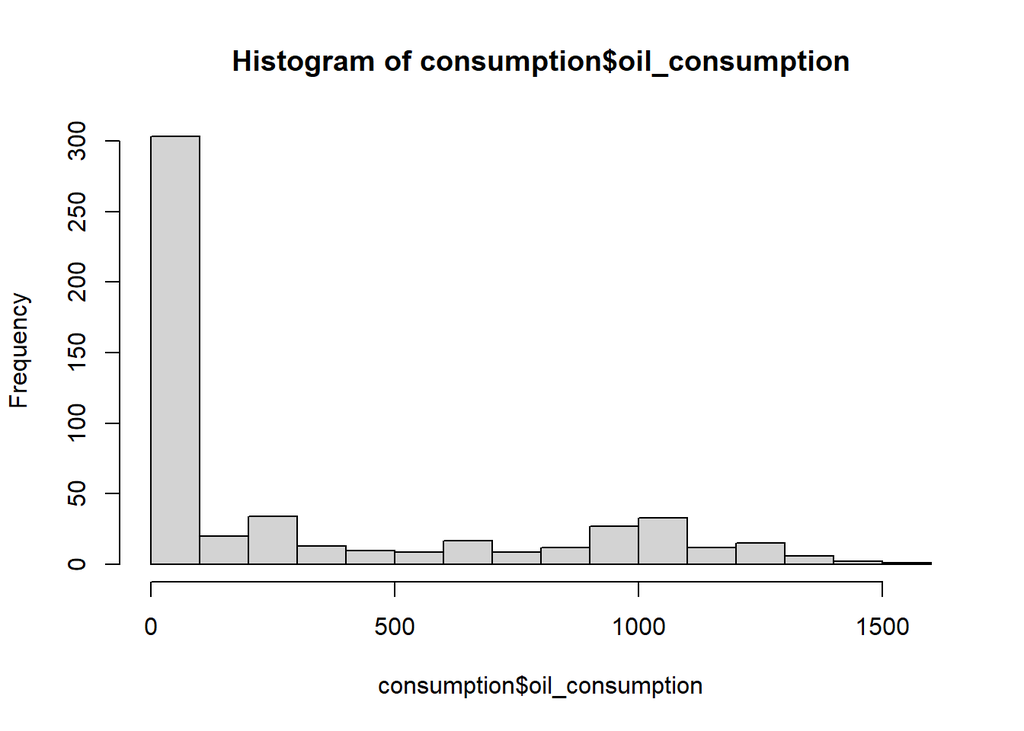

```r
hist(consumption$oil_consumption)
```

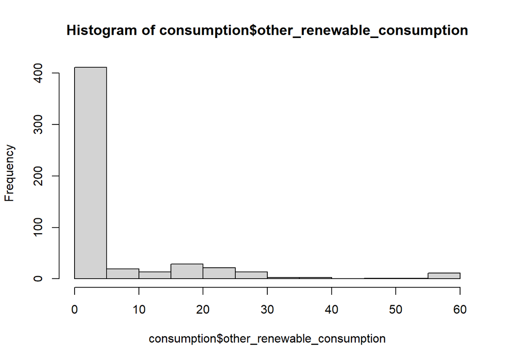

```r
hist(consumption$other_renewable_consumption)
```

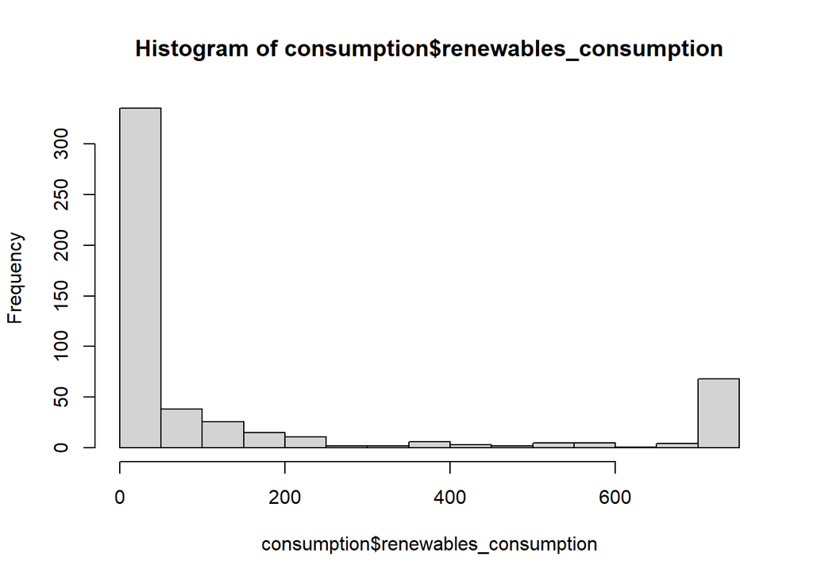

```r
hist(consumption$renewables_consumption)
```

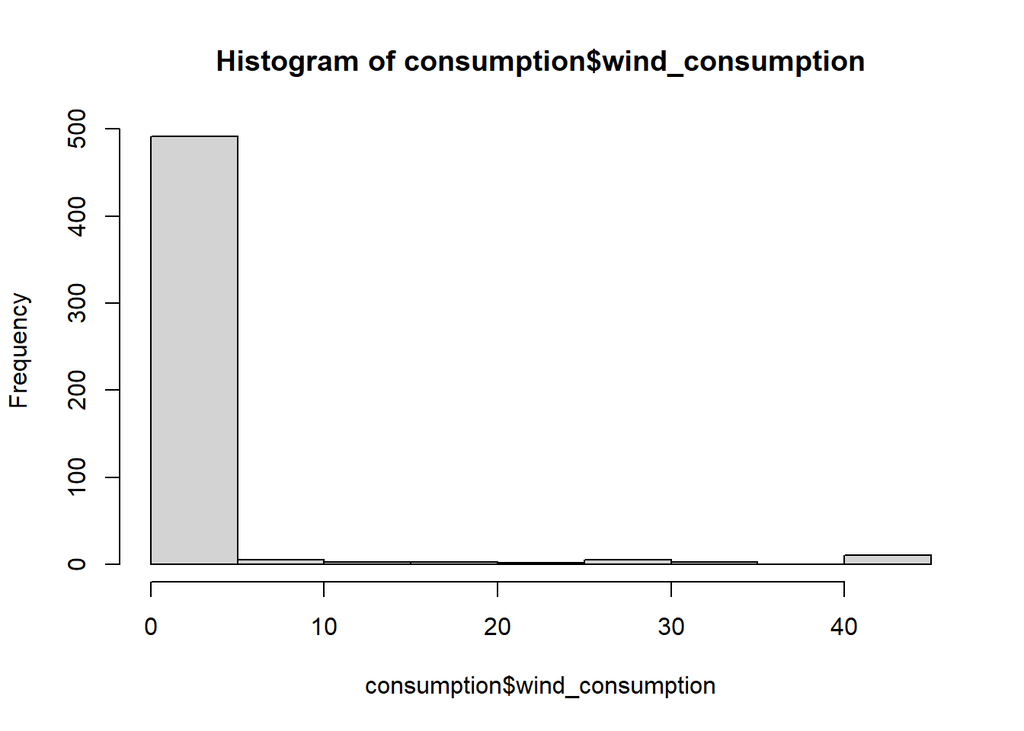

```r
hist(consumption$wind_consumption)
```

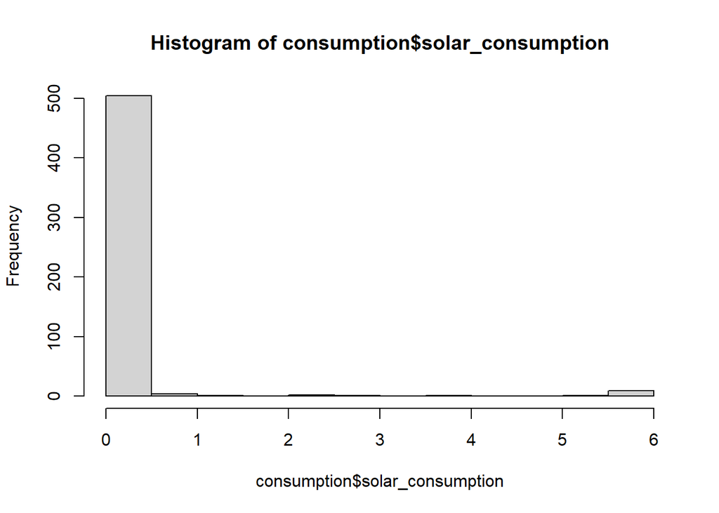

```r
hist(consumption$solar_consumption)
```

For the distribution, we saw that the data of all the variables behaves almost the same, most of the registries are in the first places and then went down to the final locations.

#### **Energy consumption per country**

To know the consumption of each energy in each country in the last year, we had to filter only the data registered in 2019, and then group it by country. However, if we wanted to analyze this data, we had to rewrite it in order to make an analysis (the way in which the dataset was ordered wasn’t functional for our purposes) that’s why we used the function *tribble* to create a new data frame ordered as we wanted. With that data, we calculated the percentages and then did the pie charts by country and energy type to understand what happened in the last year registered (2019).

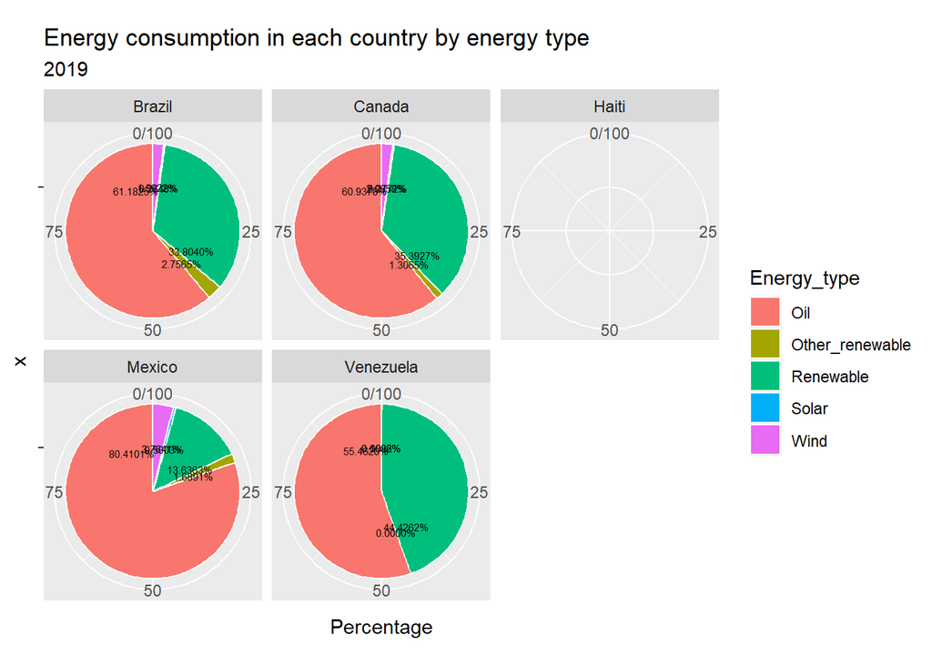

```r
consumption_2019<-consumption%>%
  filter(year==2019)%>%
  group_by(country)

consumption_2019_tb<-tribble(
  ~Country, ~Energy_type, ~Consumption,
  "Brazil", "Oil",        1314,
  "Brazil", "Other_renewable", 59.2,
  "Brazil", "Renewable",  726,
  "Brazil", "Wind",       42.786,
  "Brazil", "Solar",      5.687,
  "Canada", "Oil",        1250,
  "Canada", "Other_renewable", 26.8,
  "Canada", "Renewable",  726,
  "Canada", "Wind",       42.786,
  "Canada", "Solar",      5.687,
  "Haiti",  "Oil",        0,
  "Haiti",  "Other_renewable", 0,
  "Haiti",  "Renewable",  0,
  "Haiti",  "Wind",       0,
  "Haiti",  "Solar",      0,
  "Mexico", "Oil",        914,
  "Mexico", "Other_renewable", 19.2,
  "Mexico", "Renewable",  155,
  "Mexico", "Wind",       42.786,
  "Mexico", "Solar",      5.687,
  "Venezuela",  "Oil",        196,
  "Venezuela",  "Other_renewable", 0,
  "Venezuela",  "Renewable",  157,
  "Venezuela",  "Wind",       0.366,
  "Venezuela",  "Solar",      0.029,
)

consumption_2019_tb<-consumption_2019_tb%>%
  group_by(Country)%>%
  mutate(Total=sum(Consumption), Percentage=Consumption/Total*100)

ggplot(data=consumption_2019_tb,aes(x="",y=Percentage, fill=Energy_type))+
  geom_bar(stat = "identity",color="white")+
    geom_text(aes(label=percent(Percentage/100)),
              position=position_stack(vjust=0.9),color="black",size=2)+
  coord_polar(theta="y")+
  facet_wrap(~Country)+
  labs(title="Energy consumption in each country by energy type",
       subtitle="2019")
```

As we see, oil is the energy with a major presence in the countries, and it is followed by renewables. Sadly, we don’t have information about Haiti.

#### **Growth**

To look for the growth of these energies in each country we used the function *geom_line* and *facet_wrap* to achieve this.

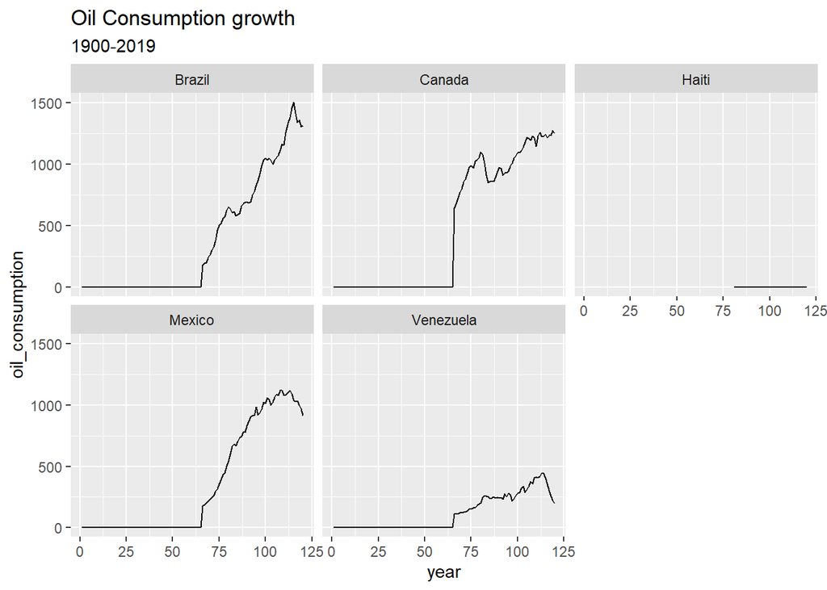

```r
consumption_graphs<-consumption%>%
  mutate(year=as.numeric(year))%>%
  filter(year!=121)

ggplot(data=consumption_graphs, mapping=aes(x=year, y=oil_consumption))+
  geom_line()+
  facet_wrap(~country)+
  labs(title="Oil Consumption growth",
        subtitle="1900-2019")
```

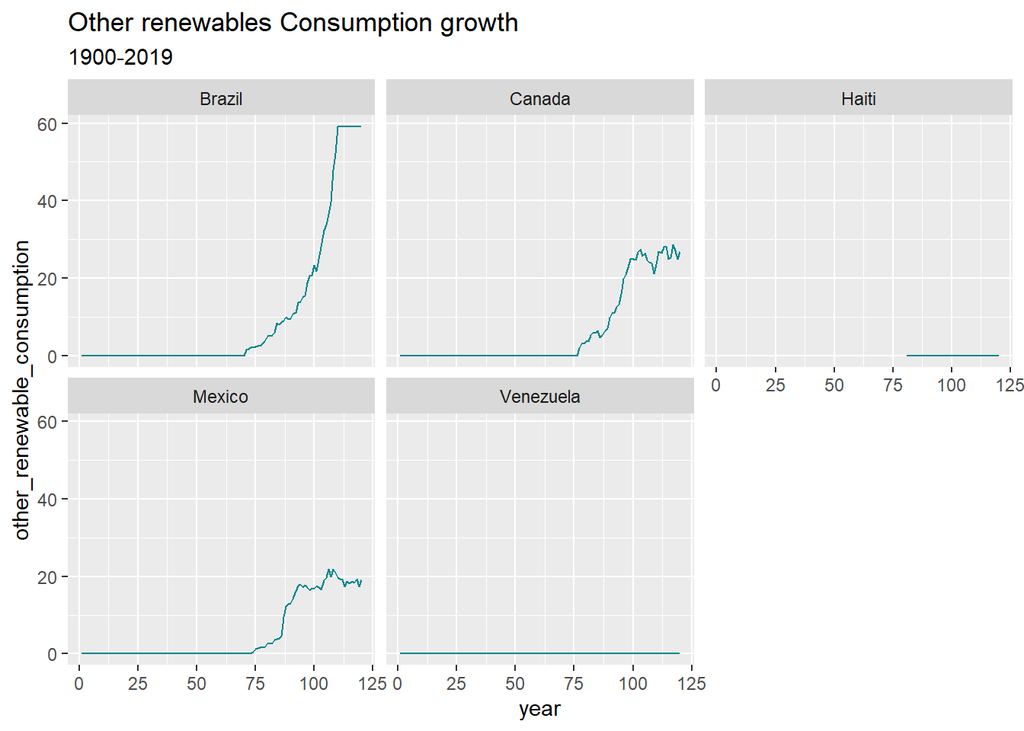

```r
ggplot(data=consumption_graphs, mapping=aes(x=year, y=other_renewable_consumption))+
  geom_line( color="turquoise4")+
  facet_wrap(~country)+
  labs(title="Other renewables Consumption growth",
        subtitle="1900-2019")
```

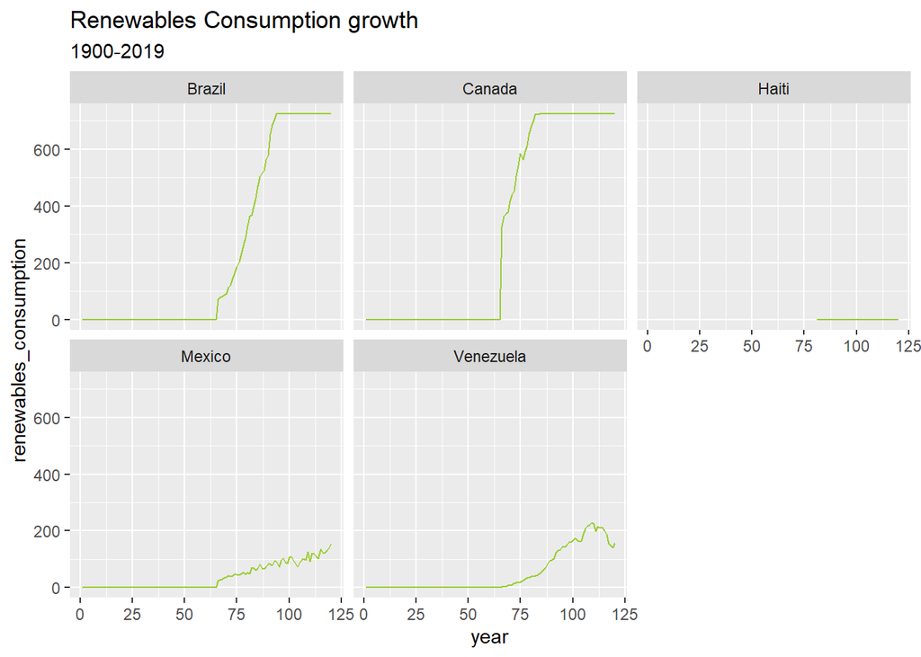

```r
ggplot(data=consumption_graphs, mapping=aes(x=year, y=renewables_consumption))+
  geom_line( color="olivedrab3")+
  facet_wrap(~country)+
  labs(title="Renewables Consumption growth",
        subtitle="1900-2019")
```

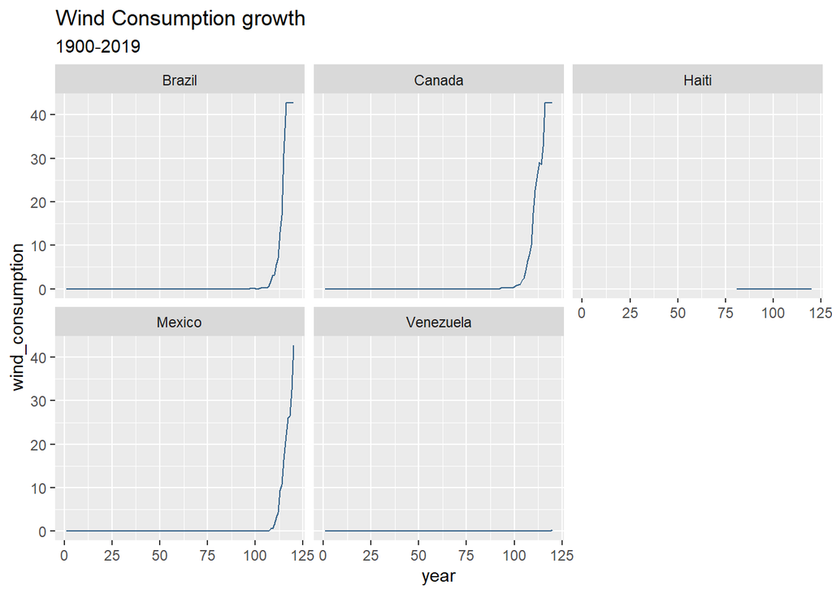

```r
ggplot(data=consumption_graphs, mapping=aes(x=year, y=wind_consumption))+
  geom_line( color="steelblue4")+
  facet_wrap(~country)+
  labs(title="Wind Consumption growth",
        subtitle="1900-2019")
```

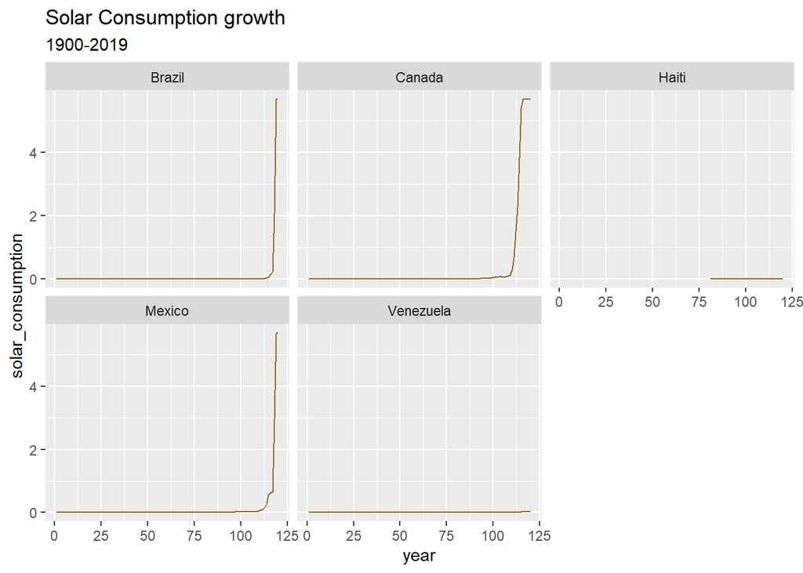

```r
ggplot(data=consumption_graphs, mapping=aes(x=year, y=solar_consumption))+
  geom_line( color="goldenrod4")+
  facet_wrap(~country)+
  labs(title="Solar Consumption growth",
        subtitle="1900-2019")
```

We found that Oil consumption had increased in Canada, Brazil, Mexico, and Venezuela but the Latin American countries went down in the final years. With other renewables, Canada and Mexico presented a growth, the same as Brazil which was bigger and maintained in the last years. In Wind and Solar, we see a big increase in the last few years.

### **Transactions**

In our last database Statistics, we have information about transactions made between countries regarding commodities used for energy.

*In which units are measured?*

First, we want to know which units are calculated in these transactions while it changes depending on the commodity we are talking about. For this, we created a new object named “measures” and counted the commodity transactions and units. The informations is the following:

```r
measures<-statistics%>%
  count(commodity_transaction, unit)%>%
  select(commodity_transaction, unit)

measures
```

```
##                             commodity_transaction                   unit
## 1                  Brown coal - final consumption Metric tons,  thousand
## 2       Brown coal briquettes - final consumption Metric tons,  thousand
## 3 Natural gas (including LNG) - final consumption             Terajoules
## 4              Petroleum coke - final consumption Metric tons,  thousand
```

#### **Average and Standard Deviation**

**Average and Standard Deviation by Commodity Transaction**

To know the average and standard deviation of each commodity transacted, we grouped the commodities, summarize calculating the mean and standard deviation, and merged it with the last object created “measures”:

```r
mean_sd_transaction<-statistics%>%
  group_by(commodity_transaction)%>%
  summarize(mean=mean(quantity), sd=sd(quantity))%>%
  merge(measures)

mean_sd_transaction
```

```
##                             commodity_transaction       mean         sd
## 1                  Brown coal - final consumption    1575.38    853.100
## 2       Brown coal briquettes - final consumption       3.67      0.577
## 3 Natural gas (including LNG) - final consumption 1055591.35 865064.320
## 4              Petroleum coke - final consumption    2704.83   2055.401
##                     unit
## 1 Metric tons,  thousand
## 2 Metric tons,  thousand
## 3             Terajoules
## 4 Metric tons,  thousand
```

**Average and Standard Deviation by Commodity Transaction and country**

To calculate this same information but divided by country, we made almost the same but grouped by country as well, so we found the following information.

```r
mean_sd_transaction_country<-statistics%>%
  group_by(country_or_area, commodity_transaction)%>%
  summarize(mean=mean(quantity), sd=sd(quantity))%>%
  merge(measures)
mean_sd_transaction_country
```

```
##                             commodity_transaction country_or_area       mean
## 1                  Brown coal - final consumption          Canada    1424.80
## 2                  Brown coal - final consumption          Mexico    1844.29
## 3       Brown coal briquettes - final consumption          Mexico       3.67
## 4 Natural gas (including LNG) - final consumption          Brazil  327748.84
## 5 Natural gas (including LNG) - final consumption          Canada 2243250.44
## 6 Natural gas (including LNG) - final consumption          Mexico  595774.76
## 7              Petroleum coke - final consumption          Brazil    4063.72
## 8              Petroleum coke - final consumption          Canada    1932.36
## 9              Petroleum coke - final consumption          Mexico    2038.45
##           sd                   unit
## 1    563.211 Metric tons,  thousand
## 2   1191.748 Metric tons,  thousand
## 3      0.577 Metric tons,  thousand
## 4 184017.627             Terajoules
## 5 170716.093             Terajoules
## 6  54667.931             Terajoules
## 7   2782.783 Metric tons,  thousand
## 8    529.903 Metric tons,  thousand
## 9   1318.512 Metric tons,  thousand
```

#### **Distribution**

We also looked for the distribution divided by unit and commodity (we can’t combine data or units in this case). To do this we made new objects where we filtered the name of each commodity and did the graph based on it.

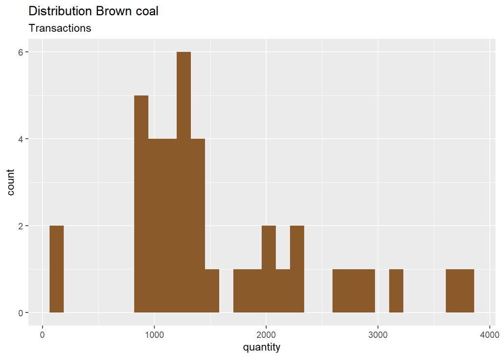

```r
distribution_statistics_brcoal<-statistics%>%
  filter(commodity_transaction=="Brown coal - final consumption")%>%
  mutate(year=as.numeric(year))

ggplot(data=distribution_statistics_brcoal, mapping=aes(x=quantity))+
  geom_histogram(fill="tan4")+
  labs(title="Distribution Brown coal",
       subtitle="Transactions")
```

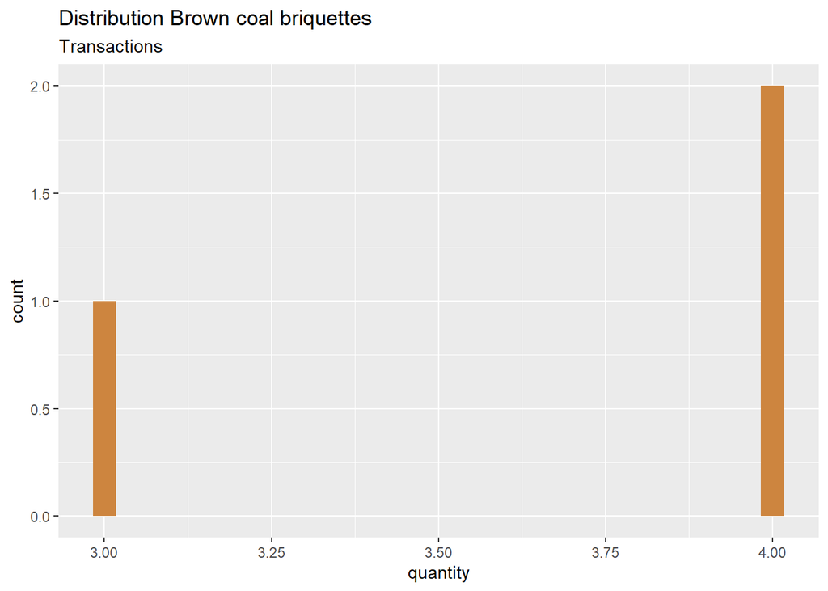

```r
distribution_statistics_brcoalbriq<-statistics%>%
  filter(commodity_transaction=="Brown coal briquettes - final consumption")%>%
  mutate(year=as.numeric(year))

ggplot(data=distribution_statistics_brcoalbriq, mapping=aes(x=quantity))+
  geom_histogram(fill="tan3")+
  labs(title="Distribution Brown coal briquettes",
       subtitle="Transactions")
```

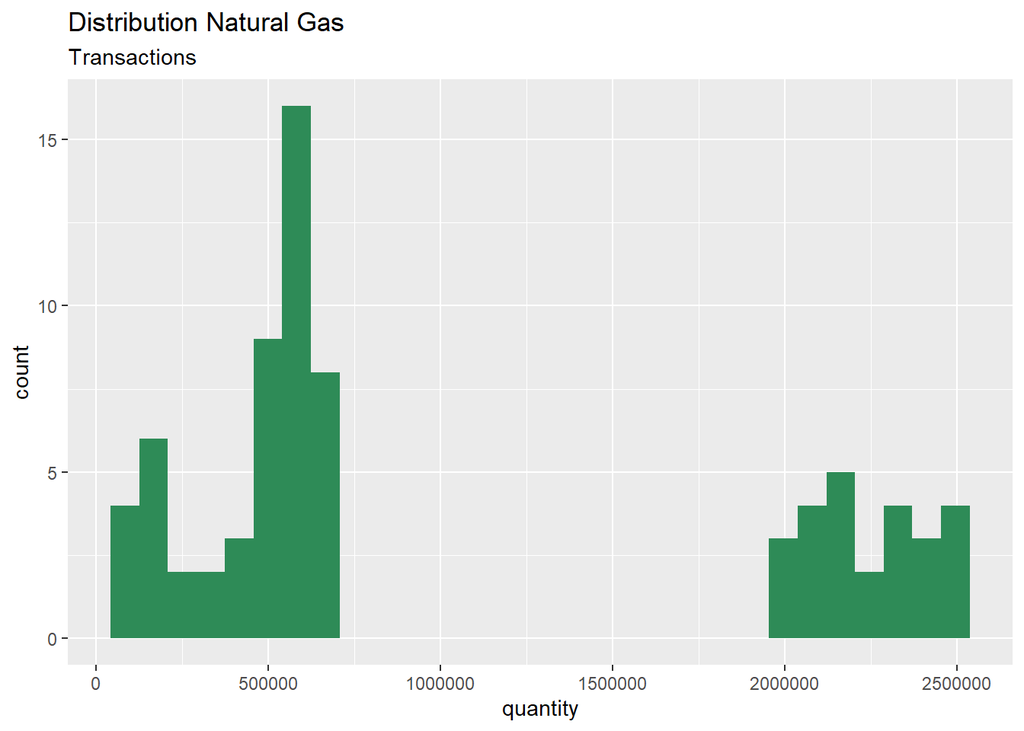

```r
distribution_statistics_natgas<-statistics%>%
  filter(commodity_transaction=="Natural gas (including LNG) - final consumption")%>%
  mutate(year=as.numeric(year))

ggplot(data=distribution_statistics_natgas, mapping=aes(x=quantity))+
  geom_histogram(fill="seagreen4")+
  labs(title="Distribution Natural Gas",
       subtitle="Transactions")
```

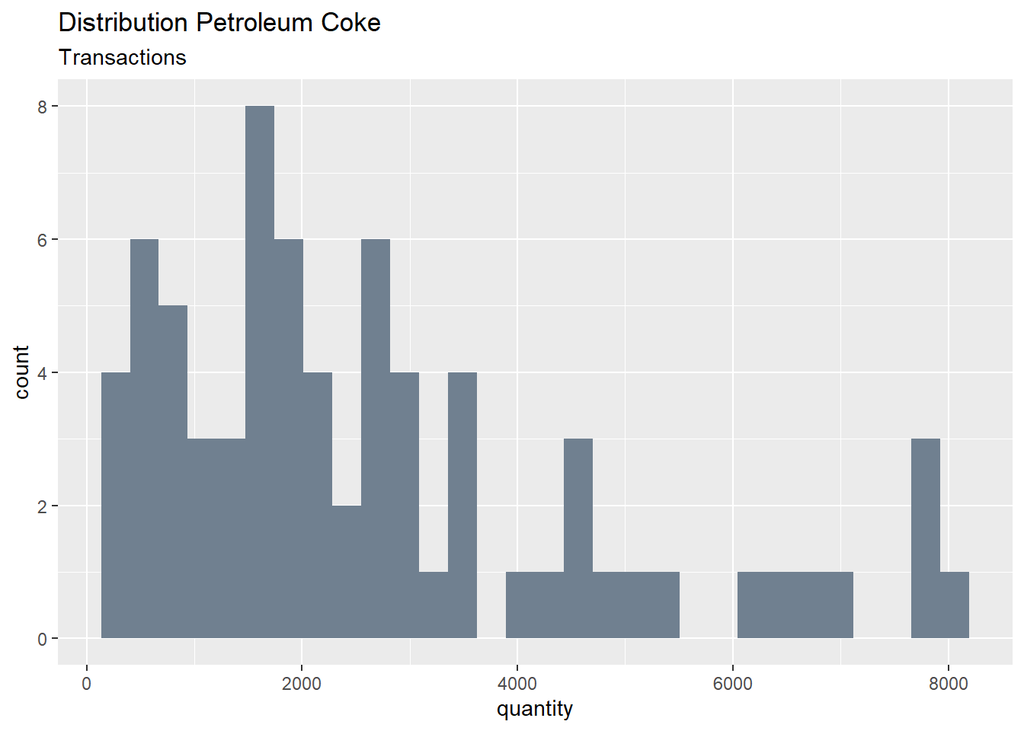

```r
distribution_statistics_pet<-statistics%>%
  filter(commodity_transaction=="Petroleum coke - final consumption")%>%
  mutate(year=as.numeric(year))

ggplot(data=distribution_statistics_pet, mapping=aes(x=quantity))+
  geom_histogram(fill="slategrey")+
  labs(title="Distribution Petroleum Coke",
       subtitle="Transactions")
```

#### **Growth**

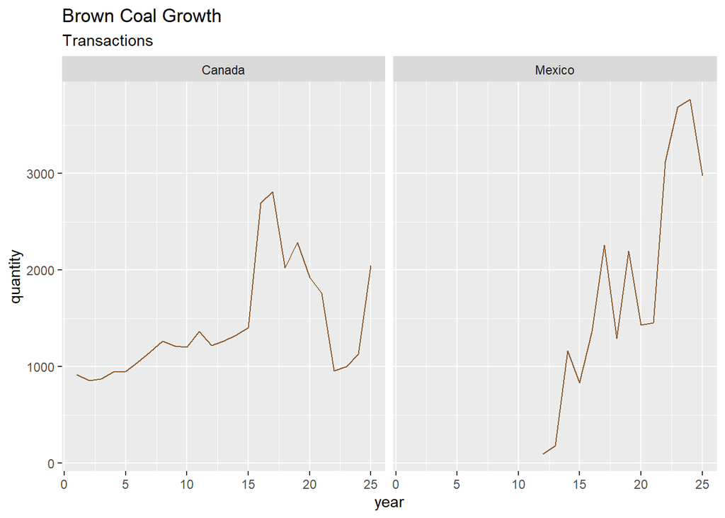

```r
ggplot(data=distribution_statistics_brcoal, mapping=aes(x=year, y=quantity))+
  geom_line(color="tan4")+
  facet_wrap(~country_or_area)+
  labs(title="Brown Coal Growth",
       subtitle="Transactions")
```

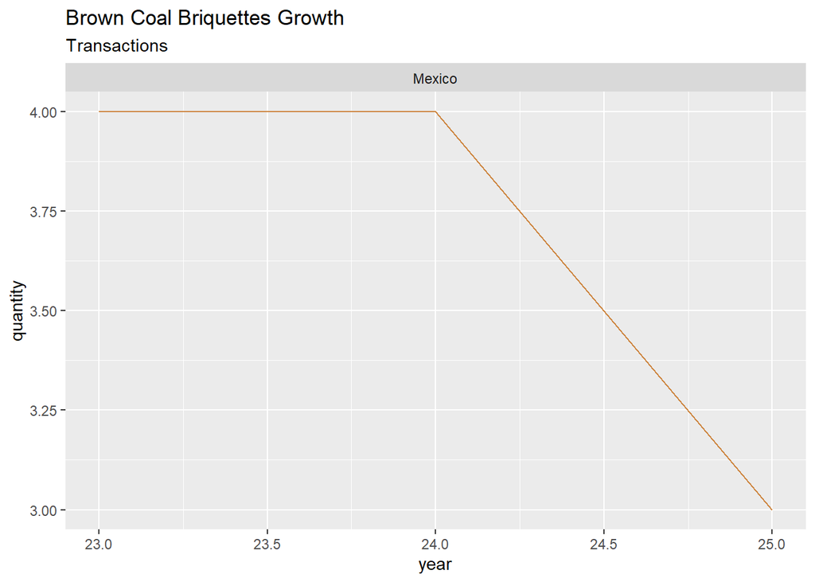

```r
ggplot(data=distribution_statistics_brcoalbriq, mapping=aes(x=year, y=quantity))+
  geom_line(color="tan3")+
  facet_wrap(~country_or_area)+
  labs(title="Brown Coal Briquettes Growth",
       subtitle="Transactions")
```

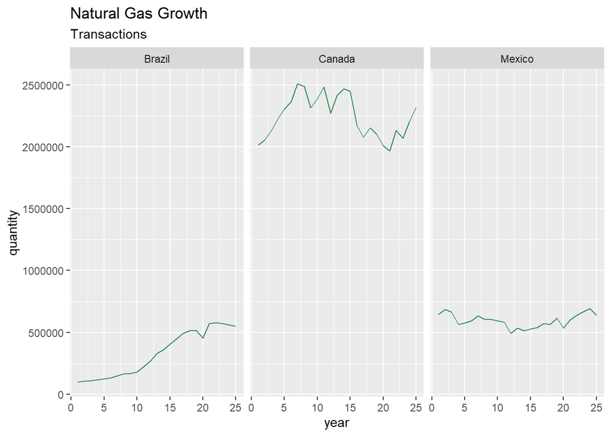

```r
ggplot(data=distribution_statistics_natgas, mapping=aes(x=year, y=quantity))+
  geom_line(color="seagreen4")+
  facet_wrap(~country_or_area)+
  labs(title="Natural Gas Growth",
       subtitle="Transactions")
```

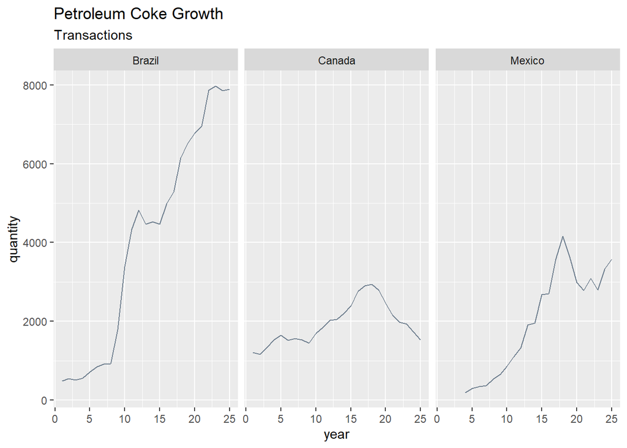

```r
ggplot(data=distribution_statistics_pet, mapping=aes(x=year, y=quantity))+
  geom_line(color="slategrey")+
  facet_wrap(~country_or_area)+
  labs(title="Petroleum Coke Growth",
       subtitle="Transactions")
```

*Which countries does not have an energy type for transactions?*

While we were doing this analysis, we found that there are some countries that are not present in the original database, which might think that doesn’t have transactions for those commodities. That’s why we wrote the next code, where we counted the countries and found that Venezuela and Haiti are not present.

```r
country_or_area_transactions<-statistics%>%
  count(country_or_area)%>%
  select(country_or_area)

country_or_area_transactions
```

```
##   country_or_area
## 1          Brazil
## 2          Canada
## 3          Mexico
```

#### **Prices**

Finally, it’s important to consider prices, and after doing an investigation, we found global prices for the most important energy types present in these three databases, we used *tribble* to create a new data frame with that information, dividing it by energy type, unit in which it is measured and price.

```r
prices<-tribble(
  ~Energy_type,  ~Unit,                     ~Price,
  "Coal",        "US$/TM",                  128,
  "Natural gas", "US$/Kwh",                 76,
  "Petroleum",   "US$ per barrel",          85,
  "Nuclear",     "US$/1000 kWh",            73,
  "Oil",         "US$ per barrel",          17.220,
  "Wind",        "US$/Kwh",                 0.066,
  "Solar",       "US$/Kwh",                 0.10
)

prices
```

```
## # A tibble: 7 × 3
##   Energy_type Unit             Price
##   <chr>       <chr>            <dbl>
## 1 Coal        US$/TM         128
## 2 Natural gas US$/Kwh         76
## 3 Petroleum   US$ per barrel  85
## 4 Nuclear     US$/1000 kWh    73
## 5 Oil         US$ per barrel  17.2
## 6 Wind        US$/Kwh          0.066
## 7 Solar       US$/Kwh          0.1
```

All these lines were written so we can make a report to take the decision, which is the best option to invest, whether in renewable energies or non-renewable or both, specifically in Brazil, Canada, Mexico, Venezuela, and Haiti.